# SLAPNAP Report: VRC07-523-LS, PGT121, PGDM1400

23 August, 2021

# 1 Executive summary

The broadly neutralizing antibodies (bnAbs) studied in this analysis are VRC07-523-LS, PGT121 and PGDM1400. The analysis considered 2 measures of neutralization sensitivity: estimated sensitivity and multiple sensitivity. Estimated IC$_{80}$ was computed based on the additive model of Wagh et al. (2016); for $J$ bnAbs, it is computed as
$$\mbox{estimated IC} = \left( \sum_{j=1}^J \mbox{IC}_j^{-1} \right)^{-1} \ ,$$
where $\mbox{IC}_j$ denotes the measured IC$_{80}$ for bnAb $j$. Estimated sensitivity is defined by the binary indicator that estimated IC$_{80}$ < 1. Multiple sensitivity is defined as the binary indicator of having measured IC$_{80}$ < 1 for at least 1 bnAb. Based on this specification of bnAbs and outcomes:

- 402 sequences were extracted from the CATNAP database (Yoon et al. 2015);
- 402 sequences had complete geographic and genetic sequence information;
- 400 of these sequences had measured IC$_{80}$;
- out of the sequences with complete data, 374 were estimated to be sensitive to the combination of bnAbs, while 26 were estimated to be resistant;
- out of the sequences with complete data, 371 were estimated to be sensitive to at least 1 bnAb, while 29 were estimated to be resistant to all of the bnAbs.

Prediction of each outcome was performed using a super learner ensemble (van der Laan, Polley, and Hubbard 2007) of several random forests (Breiman 2001) with varied tuning parameters, several gradient boosted trees (Chen and Guestrin 2016) with varied tuning parameters, and several elastic net regressions (Zou and Hastie 2005) with varied tuning parameters and intercept-only regression. Each algorithm (excepting xgboost)was additionally implemented in combination with variable pre-screening procedures to ensure that all binary features had at least 0, 4 minority variants. This constituted a total of 4863/4875, 2817/4875 features, respectively.

The specific algorithms used in the learning process are described in Table 1.1.

Table 1.1: Algorithms used in the super learner library. Each algorithm (excepting xgboost)was additionally implemented in combination with variable pre-screening procedures to ensure that all binary features had at least 0, 4 minority variants.

| Label | Description |
| --- | --- |
| rf_tune1 | random forest with `mtry` equal to one-half times square root of number of predictors |
| rf_default | random forest with `mtry` equal to square root of number of predictors |
| rf_tune2 | random forest with `mtry` equal to two times square root of number of predictors |
| xgboost_default | boosted regression trees with maximum depth of 4 |
| xgboost_tune3 | boosted regression trees with maximum depth of 8 |
| xgboost_tune4 | boosted regression trees with maximum depth of 12 |
| lasso_default | elastic net with $\lambda$ selected by 5-fold CV and $\alpha$ equal to 1 (i.e., the lasso) |
| lasso_tune1 | elastic net with $\lambda$ selected by 5-fold CV and $\alpha$ equal to 0.25 |
| lasso_tune2 | elastic net with $\lambda$ selected by 5-fold CV and $\alpha$ equal to 0.5 |
| lasso_tune3 | elastic net with $\lambda$ selected by 5-fold CV and $\alpha$ equal to 0.75 |
| mean | intercept only regression |

The predictive ability of the learner was assessed using cross-validation. The estimated cross-validated area under the receiver operating characteristic curve (AUC) of the learner for predicting binary sensitivity measures are shown in Table 1.2.

Table 1.2: Estimates of 5-fold cross-validated AUC for predictions of the binary-valued outcomes (n = 400).

|  | CV-AUC | Lower 95% CI | Upper 95% CI |
| --- | --- | --- | --- |
| Estimated sensitivity | 0.730 | 0.499 | 0.879 |
| Multiple sensitivity | 0.708 | 0.454 | 0.876 |

We define the marginal intrinsic importance of a subgroup of features as the difference in population predictiveness between the best possible prediction function based on the features under consideration plus geographic confounders versus only geographic confounders (B. D. Williamson et al. 2020). In Table 1.3, we display the groups of variables and their ranked marginal intrinsic variable importance for predicting each outcome. The groups are displayed in order of decreasing average rank across outcomes. For variable group definitions, please refer to Table 4.1.

Table 1.3: Ranked marginal variable importance of groups relative to the group of geographic confounders for predicting each outcome. Importance is measured via AUC for binary outcomes (Estimated sensitivity, Multiple sensitivity). Stars next to ranks denote groups with p-value less than 0.05 from a hypothesis test with null hypothesis of zero importance. (n = 400; for estimating the predictiveness based on the feature group of interest, n = 239; for estimating the predictiveness based on the group of geographic confounders, n = 161)

| Variable group | Estimated sensitivity | Multiple sensitivity |
| --- | --- | --- |
| gp120 V2 | 2* | 1* |
| gp120 CD4 binding sites | 1* | 4* |
| gp120 V3 | 3 | 2* |
| Region-specific counts of PNG sites | 5 | 5 |
| gp41 MPER | 7 | 3* |
| Viral geometry | 4 | 7 |
| Cysteine counts | 6 | 6 |

We define the conditional intrinsic importance of a subgroup of features for predicting an outcome as the difference in population predictiveness between the best possible prediction function based on all available features versus all features except those under consideration (B. D. Williamson et al. 2020). In Table 1.4, we display the groups of variables and their ranked conditional intrinsic variable importance for predicting each outcome. The groups are displayed in order of decreasing average rank across outcomes. For variable group definitions, please refer to Table 4.1.

Table 1.4: Ranked conditional variable importance of groups relative to the remaining features for predicting each outcome. Importance is measured via AUC for binary outcomes (Estimated sensitivity, Multiple sensitivity). Stars next to ranks denote groups with p-value less than 0.05 from a hypothesis test with null hypothesis of zero importance. (n = 400; for estimating the predictiveness based on all available features, n = 239; for estimating the predictiveness based on the reduced set of features (defined by removing the feature group of interest), n = 161)

| Variable group | Estimated sensitivity | Multiple sensitivity |
| --- | --- | --- |
| gp120 V2 | 1* | 1* |
| Region-specific counts of PNG sites | 4 | 3 |
| Viral geometry | 3 | 4 |
| gp120 CD4 binding sites | 5 | 2 |
| gp41 MPER | 2 | 5 |
| Cysteine counts | 6 | 6 |
| gp120 V3 | 7 | 7 |

# 2 Results for estimated sensitivity

## 2.1 Descriptive statistics

Out of the sequences with complete data, 374 were sensitive to the combination of bnAbs, while 26 were resistant, where estimated sensitivity was defined as the indicator that estimated IC$_{80}$ was less than 1.

## 2.2 Super learner results

The weights assigned to each algorithm for Super Learner predicting estimated sensitivity are shown in Table 2.1.

Table 2.1: Table of super learner weights for estimated sensitivity (n = 400 observations).

| Learner | Weight |
| --- | --- |
| rf_tune1_screen0 | 0.22 |
| rf_default_screen0 | 0.00 |
| rf_tune2_screen0 | 0.00 |
| lasso_default_screen0 | 0.00 |
| lasso_tune1_screen0 | 0.00 |
| lasso_tune2_screen0 | 0.00 |
| lasso_tune3_screen0 | 0.00 |
| rf_tune1_screen4 | 0.00 |
| rf_default_screen4 | 0.45 |
| rf_tune2_screen4 | 0.34 |
| lasso_default_screen4 | 0.00 |
| lasso_tune1_screen4 | 0.00 |
| lasso_tune2_screen4 | 0.00 |
| lasso_tune3_screen4 | 0.00 |
| xgboost_default | 0.00 |
| xgboost_tune3 | 0.00 |
| xgboost_tune4 | 0.00 |
| mean | 0.00 |

## 2.3 Predictive performance

The cross-validated area under the ROC curve of super learner predictions of estimated sensitivity relative to candidate algorithms is shown in Figure 2.1. Figure 2.2 shows cross-validated ROC curves for this endpoint.

The cross-validated area under the ROC curve of the learner with tuning parameters and optimal pre-screening selected via cross-validation and learners with each individual value of tuning parameters are shown in Figure 2.2.

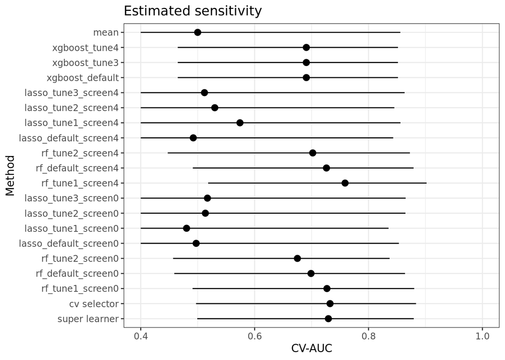

Figure 2.1: Cross-validated AUC for predicting estimated sensitivity (n = 400 observations).

Figure 2.2 shows the cross-validated ROC curve for predicting estimated sensitivity.

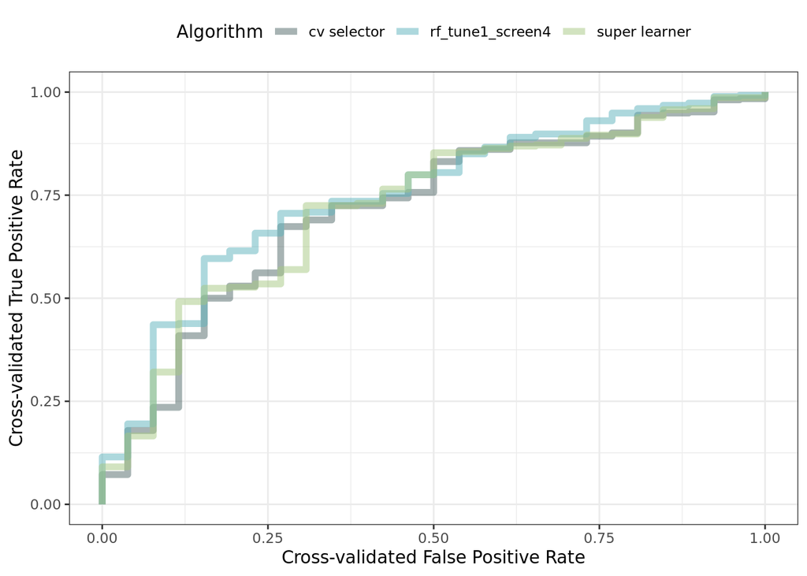

Figure 2.2: Cross-validated ROC curve for the super learner, discrete super learner, and single best performing algorithm for predicting estimated sensitivity (n = 400 observations).

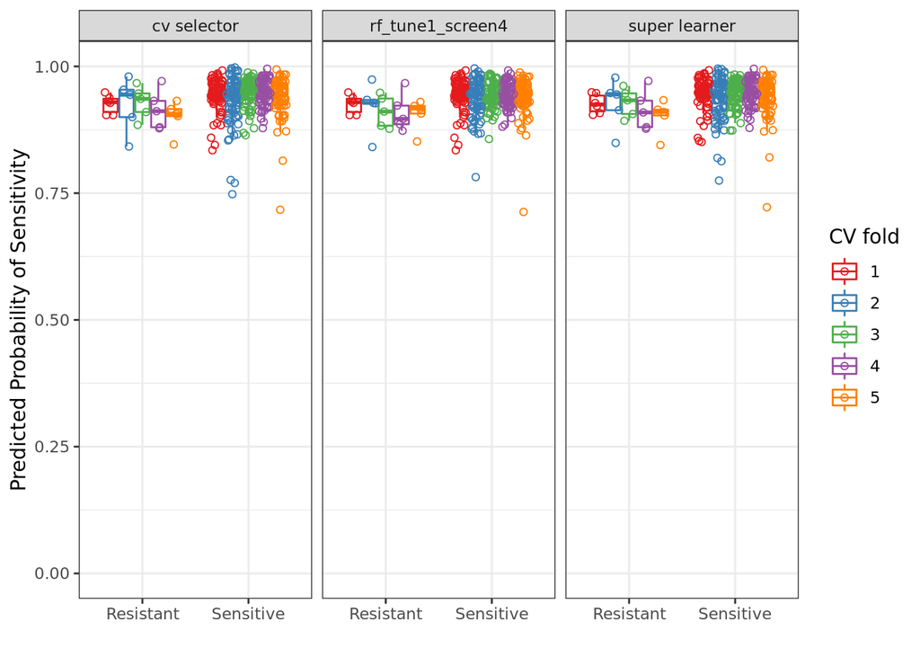

Figure 2.3: Cross-validated predicted probabilities of estimated sensitivity made by super learner, discrete super learner, and single best performing algorithm colored by cross-validation fold (n = 400 observations).

## 2.4 Variable importance

### 2.4.1 Intrinsic importance

We show the intrinsic variable importance of groups of features (defined in Table 4.1) in predicting estimated sensitivity in Figure 2.4. Importance is defined using the difference in AUCs. The left-hand plot shows the marginal intrinsic importance of the group relative to the null model with geographic confounders only. The right-hand plot shows the conditional importance of the group relative to all other groups.

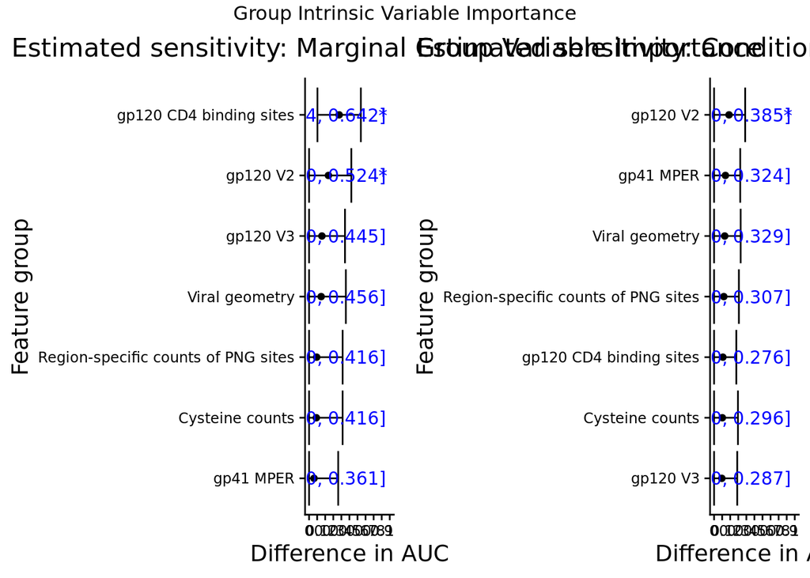

Figure 2.4: Group intrinsic variable importance for predicting estimated sensitivity. 95% confidence intervals and stars denoting p-values less than 0.05 are displayed in blue. (n = 400; for estimating the predictivenesss based on all available features and geographic confounders only, n = 239; for estimating the predictivenesss based on the reduced set of features (defined by removing the feature group of interest) and the feature group of interest plus geographic confounders, n = 161)

We show the intrinsic variable importance of individual sites, subtype variables, and viral geometry variables in predicting estimated sensitivity in Figure 2.5. Importance is defined using the difference in AUCs. The plot shows the marginal intrinsic importance of the feature relative to the null model with geographic confounders only.

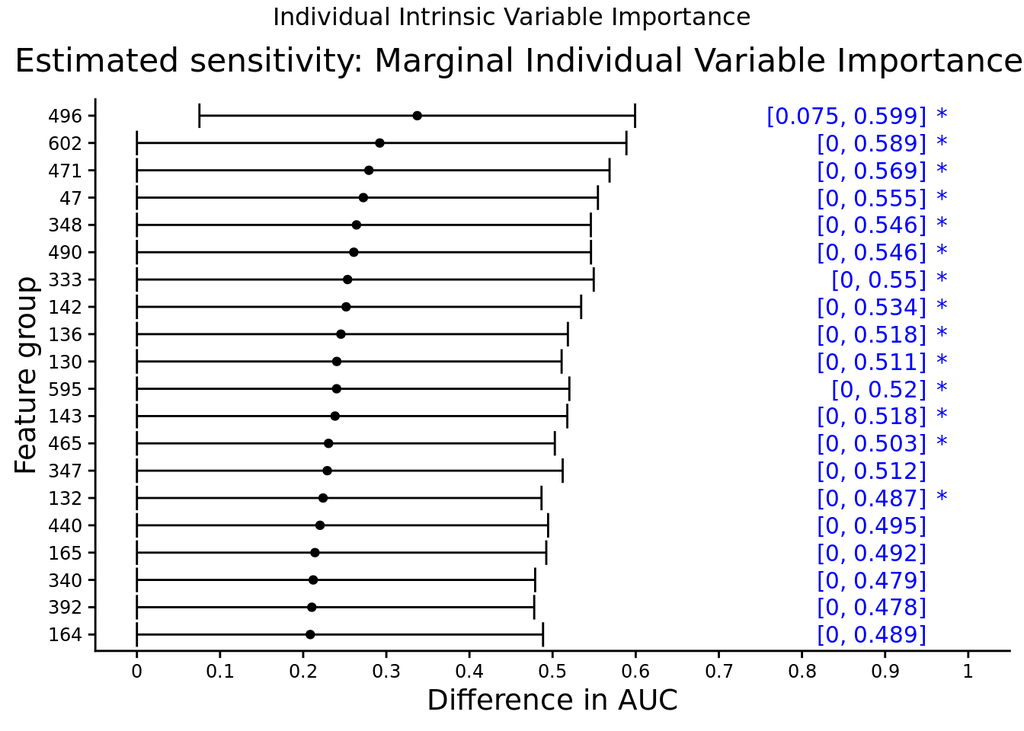

Figure 2.5: Individual intrinsic variable importance for predicting estimated sensitivity. 95% confidence intervals and stars denoting p-values less than 0.05 are displayed in blue. (n = 400; for estimating the predictiveness based on geographic confounders only, n = 239; for estimating the predictiveness based on the feature of interest plus geographic confounders, n = 161)

### 2.4.2 Predictive importance

Table 2.2 shows the top 20 features in terms of their predictive importance. Specifically, the algorithm with the largest weight in the super learner ensemble was selected and associated variable importance metrics for this algorithm are shown. In this case, the highest weight was assigned to a `rf` algorithm, and thus the variable importance measures presented correspond to random forest impurity importance measures. Impurity is computed by taking a normalized sum of the decrease in impurity (i.e., Gini index for binary outcomes; mean squared-error for continuous outcomes) over all nodes in the forest at which a split on that feature has been conducted.

Table 2.2: The top 20 important features for predicting estimated sensitivity as measured by their algorithm-specific importance.

| Feature | Importance |
| --- | --- |
| hxb2.142.K.1mer | 0.389 |
| hxb2.337.H.1mer | 0.305 |
| hxb2.822.I.1mer | 0.289 |
| hxb2.280.N.1mer | 0.228 |
| hxb2.62.V.1mer | 0.194 |
| hxb2.147.E.1mer | 0.178 |
| hxb2.317.L.1mer | 0.173 |
| hxb2.532.A.1mer | 0.161 |
| hxb2.182.L.1mer | 0.156 |
| hxb2.400.M.1mer | 0.148 |
| hxb2.304.K.1mer | 0.146 |
| hxb2.580.I.1mer | 0.145 |
| hxb2.406.R.1mer | 0.144 |
| hxb2.456.R.1mer | 0.135 |
| hxb2.188.Y.1mer | 0.130 |
| hxb2.398.H.1mer | 0.126 |
| hxb2.456.S.1mer | 0.125 |
| hxb2.307.T.1mer | 0.123 |
| hxb2.398.G.1mer | 0.123 |
| hxb2.602.H.1mer | 0.122 |

# 3 Results for multiple sensitivity

## 3.1 Descriptive statistics

Out of the 400 sequences, 371 were estimated to be sensitive to the combination of bnAbs, while 29 were estimated to be resistant, where multiple sensitivity was defined as the indicator that measured IC$_{80}$ was less than 1 for at least 1 bnAb.

## 3.2 Super learner results

The weights assigned to each algorithm for Super Learner predicting multiple sensitivity are shown in Table 3.1.

Table 3.1: Table of super learner weights for multiple sensitivity (n = 400 observations).

| Learner | Weight |
| --- | --- |
| rf_tune1_screen0 | 0.42 |
| rf_default_screen0 | 0.00 |
| rf_tune2_screen0 | 0.00 |
| lasso_default_screen0 | 0.00 |
| lasso_tune1_screen0 | 0.00 |
| lasso_tune2_screen0 | 0.00 |
| lasso_tune3_screen0 | 0.00 |
| rf_tune1_screen4 | 0.24 |
| rf_default_screen4 | 0.05 |
| rf_tune2_screen4 | 0.00 |
| lasso_default_screen4 | 0.00 |
| lasso_tune1_screen4 | 0.00 |
| lasso_tune2_screen4 | 0.00 |
| lasso_tune3_screen4 | 0.00 |
| xgboost_default | 0.29 |
| xgboost_tune3 | 0.00 |
| xgboost_tune4 | 0.00 |
| mean | 0.00 |

## 3.3 Predictive performance

The cross-validated area under the ROC curve for the super learner in predicting multiple sensitivity relative to other candidate algorithms is shown in Figure 3.1. Figure 3.2 shows cross-validated ROC curves for this endpoint.

The cross-validated area under the ROC curve for the learner with tuning parameters and optimal pre-screening selected via cross-validation and for learners with each individual value of tuning parameters are shown in Figure 3.2.

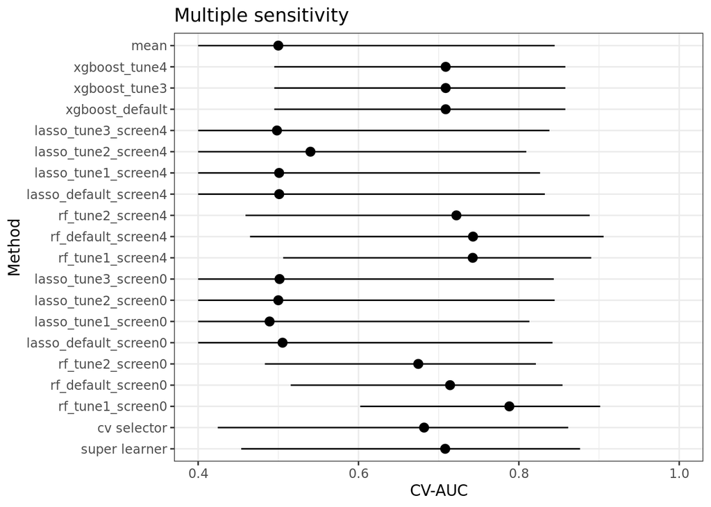

Figure 3.1: Cross-validated AUC for multiple sensitivity (n = 400 observations).

Figure 3.2 shows the cross-validated ROC curve for predicting multiple sensitivity.

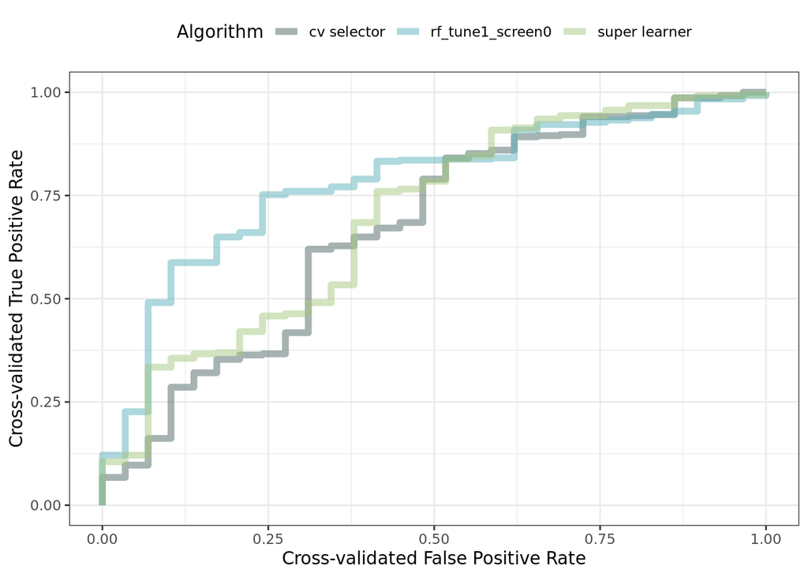

Figure 3.2: Cross-validated ROC curve for the super learner, discrete super learner, and single best performing algorithm for predicting multiple sensitivity (n = 400 observations).

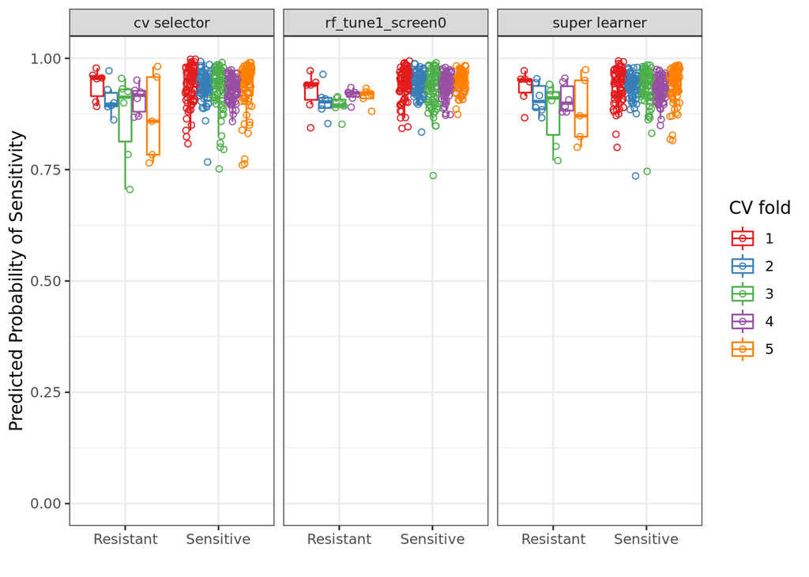

Figure 3.3: Cross-validated predicted probabilities of multiple sensitivity made by super learner, discrete super learner, and single best performing algorithm colored by cross-validation fold (n = 400 observations).

## 3.4 Variable importance

### 3.4.1 Intrinsic importance

We show the intrinsic variable importance of groups of features (defined in Table 4.1) in predicting multiple sensitivity in Figure 3.4. Importance is defined using the difference in AUCs. The left-hand plot shows the marginal intrinsic importance of the group relative to the null model with geographic confounders only. The right-hand plot shows the conditional importance of the group relative to all other groups.

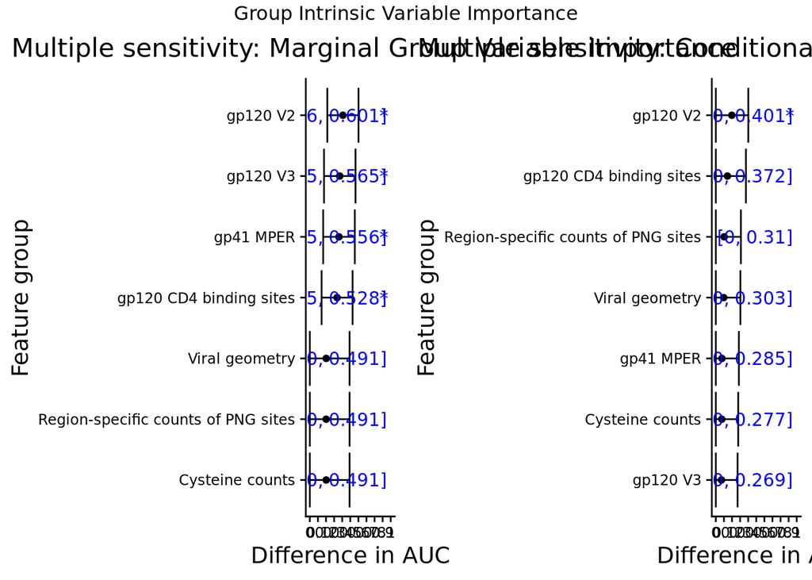

Figure 3.4: Group intrinsic variable importance for predicting multiple sensitivity. 95% confidence intervals and stars denoting p-values less than 0.05 are displayed in blue. (n = 400; for estimating the predictivenesss based on all available features and geographic confounders only, n = 239; for estimating the predictivenesss based on the reduced set of features (defined by removing the feature group of interest) and the feature group of interest plus geographic confounders, n = 161)

We show the intrinsic variable importance of individual sites, subtype variables, and viral geometry variables in predicting multiple sensitivity in Figure 3.5. Importance is defined using the difference in AUCs. The plot shows the marginal intrinsic importance of the feature relative to the null model with geographic confounders only.

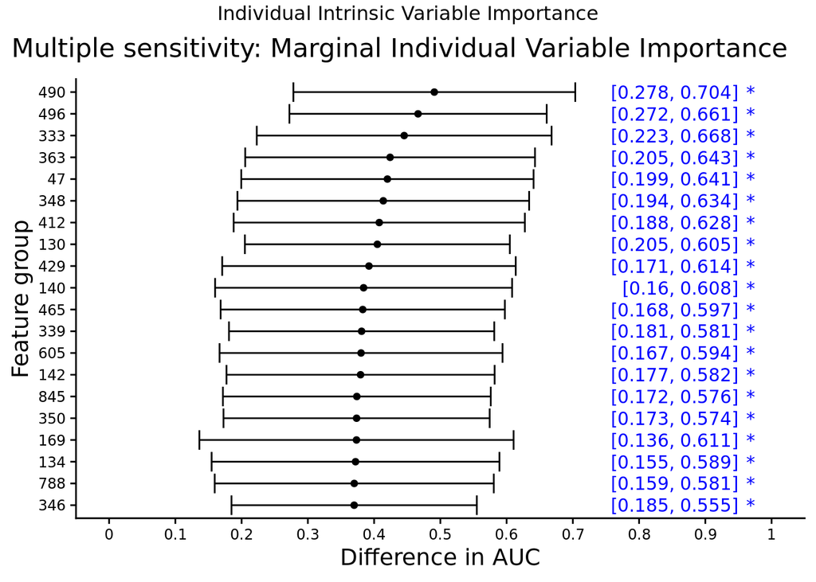

Figure 3.5: Individual intrinsic variable importance for predicting multiple sensitivity. 95% confidence intervals and stars denoting p-values less than 0.05 are displayed in blue. (n = 400; for estimating the predictiveness based on geographic confounders only, n = 239; for estimating the predictiveness based on the feature of interest plus geographic confounders, n = 161)

### 3.4.2 Predictive importance

Table 3.2 shows the top 20 features in terms of their predictive importance. Specifically, the algorithm with the largest weight in the super learner ensemble was selected and associated variable importance metrics for this algorithm are shown. In this case, the highest weight was assigned to a `rf` algorithm, and thus the variable importance measures presented correspond to random forest impurity importance measures. Impurity is computed by taking a normalized sum of the decrease in impurity (i.e., Gini index for binary outcomes; mean squared-error for continuous outcomes) over all nodes in the forest at which a split on that feature has been conducted.

Table 3.2: The top 20 important features for predicting multiple sensitivity as measured by their algorithm-specific importance.

| Feature | Importance |
| --- | --- |
| hxb2.169.Q.1mer | 0.234 |
| hxb2.365.R.1mer | 0.175 |
| hxb2.337.H.1mer | 0.144 |
| hxb2.184.T.1mer | 0.140 |
| hxb2.140.A.1mer | 0.136 |
| hxb2.240.Q.1mer | 0.131 |
| hxb2.532.A.1mer | 0.131 |
| hxb2.317.L.1mer | 0.126 |
| hxb2.398.H.1mer | 0.126 |
| hxb2.142.K.1mer | 0.125 |
| hxb2.147.E.1mer | 0.122 |
| hxb2.782.L.1mer | 0.115 |
| hxb2.440.R.1mer | 0.113 |
| hxb2.279.E.1mer | 0.109 |
| hxb2.304.K.1mer | 0.108 |
| hxb2.822.I.1mer | 0.105 |
| hxb2.182.L.1mer | 0.103 |
| hxb2.150.Q.1mer | 0.101 |
| hxb2.172.M.1mer | 0.100 |
| hxb2.602.H.1mer | 0.099 |

# 4 Variable group definitions

Table 4.1 provides the individual HXB2 coordinates and variable names of the variables that make up each of the variable groups considered for intrinsic importance.

Table 4.1: Individual variables within each variable group. Numeric codes followed by a single letter denote the presence of an amino acid (AA) residue at a given site (relative to HXB2). Other suffixes are: 'sequon_actual', referring to the site having a leading AA for the canonical N-linked glycosylation motif (N[!P]{S/T]; in other words, this AA will be an N, and the following two AAs will conform to the motif); 'gap', referring to an observed gap at this site after alignment to maintain site-specific relevance; and 'frameshift', referring to a gap at this site that resulted in a frameshift. The prefix 'num' denotes the number (e.g., 'num.cysteines' refers to the number of cysteines), while the prefix 'length' denotes the length of the specified region (excluding gaps and frameshifts).

|  | Variables |
| --- | --- |
| gp120_cd4bs | 61.F, 61.H, 61.I, 61.L, 61.Q, 61.V, 61.Y, 62.A, 62.D, 62.E, 62.G, 62.H, 62.I, 62.K, 62.N, 62.R, 62.S, 62.V, 120.I, 120.V, 124.H, 124.P, 125.F, 125.I, 125.L, 127.I, 127.V, 182.A, 182.E, 182.I, 182.K, 1… |
| gp120_v2 | 121.E, 121.K, 121.M, 121.Q, 121.R, 124.H, 124.P, 127.I, 127.V, 158.S, 158.T, 159.F, 159.L, 159.Y, 160.D, 160.H, 160.I, 160.K, 160.N, 160.R, 160.S, 160.Y, 160.gap, 161.A, 161.I, 161.L, 161.M, 161.S, 16… |
| gp120_v3 | 297.A, 297.E, 297.I, 297.L, 297.M, 297.R, 297.S, 297.T, 297.V, 299.F, 299.H, 299.L, 299.N, 299.P, 299.T, 300.A, 300.D, 300.F, 300.G, 300.H, 300.N, 300.Q, 300.S, 300.Y, 301.D, 301.E, 301.N, 301.T, 301.… |
| gp41_mper | 609.A, 609.F, 609.H, 609.K, 609.L, 609.P, 609.Q, 609.R, 609.S, 609.Y, 658.E, 658.H, 658.K, 658.L, 658.N, 658.Q, 658.R, 659.D, 659.E, 659.K, 659.N, 661.F, 661.L, 661.S, 662.A, 662.E, 662.K, 662.Q, 662.… |
| glyco | num.sequons.env, num.sequons.gp120, num.sequons.v2, num.sequons.v3, num.sequons.v5 |
| cysteines | num.cysteine.env, num.cysteine.gp120, num.cysteine.v2, num.cysteine.v5 |
| geometry | length.env, length.gp120, length.v2, length.v3, length.v5 |

# References

Breiman, Leo. 2001. “Random Forests.” *Machine Learning* 45 (1). Springer: 5–32. doi:10.1023/A:1010933404324.

Chen, Tianqi, and Carlos Guestrin. 2016. “Xgboost: A Scalable Tree Boosting System.” In *Proceedings of the 22nd Acm Sigkdd International Conference on Knowledge Discovery and Data Mining*, 785–94. doi:10.1145/2939672.2939785.

van der Laan, Mark J, Eric C Polley, and Alan E Hubbard. 2007. “Super Learner.” *Statistical Applications in Genetics and Molecular Biology* 6 (1). De Gruyter. doi:10.2202/1544-6115.1309.

Wagh, Kshitij, Tanmoy Bhattacharya, Carolyn Williamson, Alex Robles, Madeleine Bayne, Jetta Garrity, Michael Rist, et al. 2016. “Optimal Combinations of Broadly Neutralizing Antibodies for Prevention and Treatment of HIV-1 Clade C Infection.” *PLoS Pathogens* 12 (3). Public Library of Science. doi:10.1371/journal.ppat.1005520.

Williamson, Brian D, Peter B Gilbert, Noah R Simon, and Marco Carone. 2020. “A Unified Approach for Inference on Algorithm-Agnostic Variable Importance.” *arXiv Preprint*. https://arxiv.org/abs/2004.03683.

Yoon, Hyejin, Jennifer Macke, Anthony P West Jr, Brian Foley, Pamela J Bjorkman, Bette Korber, and Karina Yusim. 2015. “CATNAP: A Tool to Compile, Analyze and Tally Neutralizing Antibody Panels.” *Nucleic Acids Research* 43 (W1). Oxford University Press: W213–W219. doi:10.1093/nar/gkv404.

Zou, Hui, and Trevor Hastie. 2005. “Regularization and Variable Selection via the Elastic Net.” *Journal of the Royal Statistical Society: Series B (Statistical Methodology)* 67 (2). Wiley Online Library: 301–20. doi:10.1111/j.1467-9868.2005.00503.x.